# INN Hotels Project

## Context

A significant number of hotel bookings are called-off due to cancellations or no-shows. The typical reasons for cancellations include change of plans, scheduling conflicts, etc. This is often made easier by the option to do so free of charge or preferably at a low cost which is beneficial to hotel guests but it is a less desirable and possibly revenue-diminishing factor for hotels to deal with. Such losses are particularly high on last-minute cancellations.

The new technologies involving online booking channels have dramatically changed customers’ booking possibilities and behavior. This adds a further dimension to the challenge of how hotels handle cancellations, which are no longer limited to traditional booking and guest characteristics.

The cancellation of bookings impact a hotel on various fronts:

- Loss of resources (revenue) when the hotel cannot resell the room.
- Additional costs of distribution channels by increasing commissions or paying for publicity to help sell these rooms.
- Lowering prices last minute, so the hotel can resell a room, resulting in reducing the profit margin.
- Human resources to make arrangements for the guests.

## Objective

The increasing number of cancellations calls for a Machine Learning based solution that can help in predicting which booking is likely to be canceled. INN Hotels Group has a chain of hotels in Portugal, they are facing problems with the high number of booking cancellations and have reached out to your firm for data-driven solutions. You as a data scientist have to analyze the data provided to find which factors have a high influence on booking cancellations, build a predictive model that can predict which booking is going to be canceled in advance, and help in formulating profitable policies for cancellations and refunds.

## Data Description

The data contains the different attributes of customers' booking details. The detailed data dictionary is given below.

**Data Dictionary**

- Booking_ID: unique identifier of each booking
- no_of_adults: Number of adults
- no_of_children: Number of Children
- no_of_weekend_nights: Number of weekend nights (Saturday or Sunday) the guest stayed or booked to stay at the hotel
- no_of_week_nights: Number of week nights (Monday to Friday) the guest stayed or booked to stay at the hotel
- type_of_meal_plan: Type of meal plan booked by the customer:
  - Not Selected – No meal plan selected
  - Meal Plan 1 – Breakfast
  - Meal Plan 2 – Half board (breakfast and one other meal)
  - Meal Plan 3 – Full board (breakfast, lunch, and dinner)
- required_car_parking_space: Does the customer require a car parking space? (0 - No, 1- Yes)
- room_type_reserved: Type of room reserved by the customer. The values are ciphered (encoded) by INN Hotels.
- lead_time: Number of days between the date of booking and the arrival date
- arrival_year: Year of arrival date
- arrival_month: Month of arrival date
- arrival_date: Date of the month
- market_segment_type: Market segment designation.
- repeated_guest: Is the customer a repeated guest? (0 - No, 1- Yes)
- no_of_previous_cancellations: Number of previous bookings that were canceled by the customer prior to the current booking
- no_of_previous_bookings_not_canceled: Number of previous bookings not canceled by the customer prior to the current booking
- avg_price_per_room: Average price per day of the reservation; prices of the rooms are dynamic. (in euros)
- no_of_special_requests: Total number of special requests made by the customer (e.g. high floor, view from the room, etc)
- booking_status: Flag indicating if the booking was canceled or not.

## Importing necessary libraries and data

```python
# this will help in making the Python code more structured automatically (good coding practice)
%load_ext nb_black

import warnings

warnings.filterwarnings("ignore")
from statsmodels.tools.sm_exceptions import ConvergenceWarning

warnings.simplefilter("ignore", ConvergenceWarning)

# Libraries to help with reading and manipulating data

import pandas as pd
import numpy as np

# Library to split data
from sklearn.model_selection import train_test_split

# libaries to help with data visualization
import matplotlib.pyplot as plt
import seaborn as sns

# Removes the limit for the number of displayed columns
pd.set_option("display.max_columns", None)
# Sets the limit for the number of displayed rows
pd.set_option("display.max_rows", 200)
# sets the precision of floating numbers to 5 decimal places
pd.set_option("display.float_format", lambda x: "%5f" % x)


# To build model for prediction
import statsmodels.stats.api as sms
from statsmodels.stats.outliers_influence import variance_inflation_factor
import statsmodels.api as sm
from statsmodels.tools.tools import add_constant
from sklearn.tree import DecisionTreeClassifier
from sklearn import tree
#from sklearn.linear_model import LogisticRegression

# To tune different models
from sklearn.model_selection import GridSearchCV


# To get diferent metric scores
from sklearn.metrics import (
    f1_score,
    accuracy_score,
    recall_score,
    precision_score,
    confusion_matrix,
    roc_auc_score,
    plot_confusion_matrix,
    precision_recall_curve,
    roc_curve,
    make_scorer,
)

#from sklearn import metrics
#import matplotlib.pyplot as plt

#%matplotlib inline
#import seaborn as sns
#from sklearn.model_selection import train_test_split
```

```
The nb_black extension is already loaded. To reload it, use:
  %reload_ext nb_black
```

```python
from sklearn.datasets import load_digits

digits = load_digits()
```

```python
df_main=pd.read_csv('InnHotelsGroup.csv')
```

```python
data = df_main.copy()
```

## Data Overview

- Observations
- Sanity checks

```python
data.head()
```

|  | Booking_ID | no_of_adults | no_of_children | no_of_weekend_nights | no_of_week_nights | type_of_meal_plan | required_car_parking_space | room_type_reserved | lead_time | arrival_year | arrival_month | arrival_date | market_segment_type | repeated_guest | no_of_previous_cancellations | no_of_previous_bookings_not_canceled | avg_price_per_room | no_of_special_requests | booking_status |
| --- | --- | --- | --- | --- | --- | --- | --- | --- | --- | --- | --- | --- | --- | --- | --- | --- | --- | --- | --- |
| 0 | INN00001 | 2 | 0 | 1 | 2 | Meal Plan 1 | 0 | Room_Type 1 | 224 | 2017 | 10 | 2 | Offline | 0 | 0 | 0 | 65.000000 | 0 | Not_Canceled |
| 1 | INN00002 | 2 | 0 | 2 | 3 | Not Selected | 0 | Room_Type 1 | 5 | 2018 | 11 | 6 | Online | 0 | 0 | 0 | 106.680000 | 1 | Not_Canceled |
| 2 | INN00003 | 1 | 0 | 2 | 1 | Meal Plan 1 | 0 | Room_Type 1 | 1 | 2018 | 2 | 28 | Online | 0 | 0 | 0 | 60.000000 | 0 | Canceled |
| 3 | INN00004 | 2 | 0 | 0 | 2 | Meal Plan 1 | 0 | Room_Type 1 | 211 | 2018 | 5 | 20 | Online | 0 | 0 | 0 | 100.000000 | 0 | Canceled |
| 4 | INN00005 | 2 | 0 | 1 | 1 | Not Selected | 0 | Room_Type 1 | 48 | 2018 | 4 | 11 | Online | 0 | 0 | 0 | 94.500000 | 0 | Canceled |

```python
data.tail()
```

|  | Booking_ID | no_of_adults | no_of_children | no_of_weekend_nights | no_of_week_nights | type_of_meal_plan | required_car_parking_space | room_type_reserved | lead_time | arrival_year | arrival_month | arrival_date | market_segment_type | repeated_guest | no_of_previous_cancellations | no_of_previous_bookings_not_canceled | avg_price_per_room | no_of_special_requests | booking_status |
| --- | --- | --- | --- | --- | --- | --- | --- | --- | --- | --- | --- | --- | --- | --- | --- | --- | --- | --- | --- |
| 36270 | INN36271 | 3 | 0 | 2 | 6 | Meal Plan 1 | 0 | Room_Type 4 | 85 | 2018 | 8 | 3 | Online | 0 | 0 | 0 | 167.800000 | 1 | Not_Canceled |
| 36271 | INN36272 | 2 | 0 | 1 | 3 | Meal Plan 1 | 0 | Room_Type 1 | 228 | 2018 | 10 | 17 | Online | 0 | 0 | 0 | 90.950000 | 2 | Canceled |
| 36272 | INN36273 | 2 | 0 | 2 | 6 | Meal Plan 1 | 0 | Room_Type 1 | 148 | 2018 | 7 | 1 | Online | 0 | 0 | 0 | 98.390000 | 2 | Not_Canceled |
| 36273 | INN36274 | 2 | 0 | 0 | 3 | Not Selected | 0 | Room_Type 1 | 63 | 2018 | 4 | 21 | Online | 0 | 0 | 0 | 94.500000 | 0 | Canceled |
| 36274 | INN36275 | 2 | 0 | 1 | 2 | Meal Plan 1 | 0 | Room_Type 1 | 207 | 2018 | 12 | 30 | Offline | 0 | 0 | 0 | 161.670000 | 0 | Not_Canceled |

###### Perform one hot coding for 'booking status'. Cancelled=1, Not Cancelled=0

```python
data["booking_status"] = data["booking_status"].apply(
    lambda x: 1 if x == "Canceled" else 0
)
```

```python
data.shape
```

```
(36275, 19)
```

The data contains 36275 rows and 19 columns

```python
data.info()
```

```
<class 'pandas.core.frame.DataFrame'>
RangeIndex: 36275 entries, 0 to 36274
Data columns (total 19 columns):
 #   Column                                Non-Null Count  Dtype
---  ------                                --------------  -----
 0   Booking_ID                            36275 non-null  object
 1   no_of_adults                          36275 non-null  int64
 2   no_of_children                        36275 non-null  int64
 3   no_of_weekend_nights                  36275 non-null  int64
 4   no_of_week_nights                     36275 non-null  int64
 5   type_of_meal_plan                     36275 non-null  object
 6   required_car_parking_space            36275 non-null  int64
 7   room_type_reserved                    36275 non-null  object
 8   lead_time                             36275 non-null  int64
 9   arrival_year                          36275 non-null  int64
 10  arrival_month                         36275 non-null  int64
 11  arrival_date                          36275 non-null  int64
 12  market_segment_type                   36275 non-null  object
 13  repeated_guest                        36275 non-null  int64
 14  no_of_previous_cancellations          36275 non-null  int64
 15  no_of_previous_bookings_not_canceled  36275 non-null  int64
 16  avg_price_per_room                    36275 non-null  float64
 17  no_of_special_requests                36275 non-null  int64
 18  booking_status                        36275 non-null  int64
dtypes: float64(1), int64(14), object(4)
memory usage: 5.3+ MB
```

There are 4 object types and 15 numeric types.

```python
data.isnull().sum()
```

```
Booking_ID                              0
no_of_adults                            0
no_of_children                          0
no_of_weekend_nights                    0
no_of_week_nights                       0
type_of_meal_plan                       0
required_car_parking_space              0
room_type_reserved                      0
lead_time                               0
arrival_year                            0
arrival_month                           0
arrival_date                            0
market_segment_type                     0
repeated_guest                          0
no_of_previous_cancellations            0
no_of_previous_bookings_not_canceled    0
avg_price_per_room                      0
no_of_special_requests                  0
booking_status                          0
dtype: int64
```

There are no missing values in the dataset

```python
# check for duplicate values
data.duplicated().sum()
```

```
0
```

There are no duplicate values in the data.

```python
# Identify any columns with unique ID's
data.Booking_ID.nunique()
```

```
36275
```

```python
# Drop Booking ID since it only contains unique values
data = data.drop(["Booking_ID"], axis=1)
```

```python
data.describe().T
```

|  | count | mean | std | min | 25% | 50% | 75% | max |
| --- | --- | --- | --- | --- | --- | --- | --- | --- |
| no_of_adults | 36275.000000 | 1.844962 | 0.518715 | 0.000000 | 2.000000 | 2.000000 | 2.000000 | 4.000000 |
| no_of_children | 36275.000000 | 0.105279 | 0.402648 | 0.000000 | 0.000000 | 0.000000 | 0.000000 | 10.000000 |
| no_of_weekend_nights | 36275.000000 | 0.810724 | 0.870644 | 0.000000 | 0.000000 | 1.000000 | 2.000000 | 7.000000 |
| no_of_week_nights | 36275.000000 | 2.204300 | 1.410905 | 0.000000 | 1.000000 | 2.000000 | 3.000000 | 17.000000 |
| required_car_parking_space | 36275.000000 | 0.030986 | 0.173281 | 0.000000 | 0.000000 | 0.000000 | 0.000000 | 1.000000 |
| lead_time | 36275.000000 | 85.232557 | 85.930817 | 0.000000 | 17.000000 | 57.000000 | 126.000000 | 443.000000 |
| arrival_year | 36275.000000 | 2017.820427 | 0.383836 | 2017.000000 | 2018.000000 | 2018.000000 | 2018.000000 | 2018.000000 |
| arrival_month | 36275.000000 | 7.423653 | 3.069894 | 1.000000 | 5.000000 | 8.000000 | 10.000000 | 12.000000 |
| arrival_date | 36275.000000 | 15.596995 | 8.740447 | 1.000000 | 8.000000 | 16.000000 | 23.000000 | 31.000000 |
| repeated_guest | 36275.000000 | 0.025637 | 0.158053 | 0.000000 | 0.000000 | 0.000000 | 0.000000 | 1.000000 |
| no_of_previous_cancellations | 36275.000000 | 0.023349 | 0.368331 | 0.000000 | 0.000000 | 0.000000 | 0.000000 | 13.000000 |
| no_of_previous_bookings_not_canceled | 36275.000000 | 0.153411 | 1.754171 | 0.000000 | 0.000000 | 0.000000 | 0.000000 | 58.000000 |
| avg_price_per_room | 36275.000000 | 103.423539 | 35.089424 | 0.000000 | 80.300000 | 99.450000 | 120.000000 | 540.000000 |
| no_of_special_requests | 36275.000000 | 0.619655 | 0.786236 | 0.000000 | 0.000000 | 0.000000 | 1.000000 | 5.000000 |
| booking_status | 36275.000000 | 0.327636 | 0.469358 | 0.000000 | 0.000000 | 0.000000 | 1.000000 | 1.000000 |

The mean lead time before reservation is 85 days. Lead time ranges from 0(same day) to 443 days.

The average price per room is 103.42 euros. The maximum price is 540 euros.

###### Identify different levels in categorical variables

```python
# filter object type columns
cat_columns = data.describe(include=["object"]).columns
cat_columns
```

```
Index(['type_of_meal_plan', 'room_type_reserved', 'market_segment_type'], dtype='object')
```

```python
for i in cat_columns:
    print("Unique values in", i, "are :")
    print(data[i].value_counts())
    print("*" * 40)
```

```
Unique values in type_of_meal_plan are :
Meal Plan 1     27835
Not Selected     5130
Meal Plan 2      3305
Meal Plan 3         5
Name: type_of_meal_plan, dtype: int64
Unique values in room_type_reserved are :
Room_Type 1    28130
Room_Type 4     6057
Room_Type 6      966
Room_Type 2      692
Room_Type 5      265
Room_Type 7      158
Room_Type 3        7
Name: room_type_reserved, dtype: int64
Unique values in market_segment_type are :
Online           23214
Offline          10528
Corporate         2017
Complementary      391
Aviation           125
Name: market_segment_type, dtype: int64
```

Meal plan 1 is the most popular plan. Room type 1 is the most popular. Online booking is the most popular market segment type.

```python
# filter object type columns
num_columns = data.describe(include=["int64"]).columns
num_columns
```

```
Index(['no_of_adults', 'no_of_children', 'no_of_weekend_nights',
       'no_of_week_nights', 'required_car_parking_space', 'lead_time',
       'arrival_year', 'arrival_month', 'arrival_date', 'repeated_guest',
       'no_of_previous_cancellations', 'no_of_previous_bookings_not_canceled',
       'no_of_special_requests', 'booking_status'],
      dtype='object')
```

```python
for i in num_columns:
    print("Unique values in", i, "are :")
    print(data[i].value_counts())
    print("*" * 40)
```

```
Unique values in no_of_adults are :
2    26108
1     7695
3     2317
0      139
4       16
Name: no_of_adults, dtype: int64
Unique values in no_of_children are :
0     33577
1      1618
2      1058
3        19
9         2
10        1
Name: no_of_children, dtype: int64
```

[output cut: 186 more lines]

```python
# filter object type columns
num1_columns = data.describe(include=["float64"]).columns
num1_columns
```

```
Index(['avg_price_per_room'], dtype='object')
```

```python
for i in num1_columns:
    print("Unique values in", i, "are :")
    print(data[i].value_counts())
    print("*" * 40)
```

```
Unique values in avg_price_per_room are :
65.000000     848
75.000000     826
90.000000     703
95.000000     669
115.000000    662
             ...
212.420000      1
83.480000       1
70.420000       1
130.990000      1
167.800000      1
Name: avg_price_per_room, Length: 3930, dtype: int64
```

The most common average price per room is 65 euros, followed by 75 euros and 90 euros.

## Exploratory Data Analysis (EDA)

```python
def histogram_boxplot(data, feature, figsize=(15, 10), kde=False, bins=None):
    """
    Boxplot and histogram combined

    data: dataframe
    feature: dataframe column
    figsize: size of figure (default (15,10))
    kde: whether to show the density curve (default False)
    bins: number of bins for histogram (default None)
    """
    f2, (ax_box2, ax_hist2) = plt.subplots(
        nrows=2,  # Number of rows of the subplot grid= 2
        sharex=True,  # x-axis will be shared among all subplots
        gridspec_kw={"height_ratios": (0.25, 0.75)},
        figsize=figsize,
    )  # creating the 2 subplots
    sns.boxplot(
        data=data, x=feature, ax=ax_box2, showmeans=True, color="violet"
    )  # boxplot will be created and a triangle will indicate the mean value of the column
    sns.histplot(
        data=data, x=feature, kde=kde, ax=ax_hist2, bins=bins
    ) if bins else sns.histplot(
        data=data, x=feature, kde=kde, ax=ax_hist2
    )  # For histogram
    ax_hist2.axvline(
        data[feature].mean(), color="green", linestyle="--"
    )  # Add mean to the histogram
    ax_hist2.axvline(
        data[feature].median(), color="black", linestyle="-"
    )  # Add median to the histogram
```

```python
# function to create labeled barplots


def labeled_barplot(data, feature, perc=False, n=None):
    """
    Barplot with percentage at the top

    data: dataframe
    feature: dataframe column
    perc: whether to display percentages instead of count (default is False)
    n: displays the top n category levels (default is None, i.e., display all levels)
    """

    total = len(data[feature])  # length of the column
    count = data[feature].nunique()
    if n is None:
        plt.figure(figsize=(count + 2, 6))
    else:
        plt.figure(figsize=(n + 2, 6))

    plt.xticks(rotation=90, fontsize=15)
    ax = sns.countplot(
        data=data,
        x=feature,
        palette="Paired",
        order=data[feature].value_counts().index[:n],
    )

    for p in ax.patches:
        if perc == True:
            label = "{:.1f}%".format(
                100 * p.get_height() / total
            )  # percentage of each class of the category
        else:
            label = p.get_height()  # count of each level of the category

        x = p.get_x() + p.get_width() / 2  # width of the plot
        y = p.get_height()  # height of the plot

        ax.annotate(
            label,
            (x, y),
            ha="center",
            va="center",
            size=12,
            xytext=(0, 5),
            textcoords="offset points",
        )  # annotate the percentage

    plt.show()  # show the plot
```

```python
def stacked_barplot(data, predictor, target):
    """
    Print the category counts and plot a stacked bar chart

    data: dataframe
    predictor: independent variable
    target: target variable
    """
    count = data[predictor].nunique()
    sorter = data[target].value_counts().index[-1]
    tab1 = pd.crosstab(data[predictor], data[target], margins=True).sort_values(
        by=sorter, ascending=False
    )
    print(tab1)
    print("-" * 120)
    tab = pd.crosstab(data[predictor], data[target], normalize="index").sort_values(
        by=sorter, ascending=False
    )
    tab.plot(kind="bar", stacked=True, figsize=(count + 5, 5))
    plt.legend(
        loc="lower left", frameon=False,
    )
    plt.legend(loc="upper left", bbox_to_anchor=(1, 1))
    plt.show()
```

```python
### function to plot distributions wrt target


def distribution_plot_wrt_target(data, predictor, target):

    fig, axs = plt.subplots(2, 2, figsize=(12, 10))

    target_uniq = data[target].unique()

    axs[0, 0].set_title("Distribution of target for target=" + str(target_uniq[0]))
    sns.histplot(
        data=data[data[target] == target_uniq[0]],
        x=predictor,
        kde=True,
        ax=axs[0, 0],
        color="teal",
        stat="density",
    )

    axs[0, 1].set_title("Distribution of target for target=" + str(target_uniq[1]))
    sns.histplot(
        data=data[data[target] == target_uniq[1]],
        x=predictor,
        kde=True,
        ax=axs[0, 1],
        color="orange",
        stat="density",
    )

    axs[1, 0].set_title("Boxplot w.r.t target")
    sns.boxplot(data=data, x=target, y=predictor, ax=axs[1, 0], palette="gist_rainbow")

    axs[1, 1].set_title("Boxplot (without outliers) w.r.t target")
    sns.boxplot(
        data=data,
        x=target,
        y=predictor,
        ax=axs[1, 1],
        showfliers=False,
        palette="gist_rainbow",
    )

    plt.tight_layout()
    plt.show()
```

#### Univariate Analysis

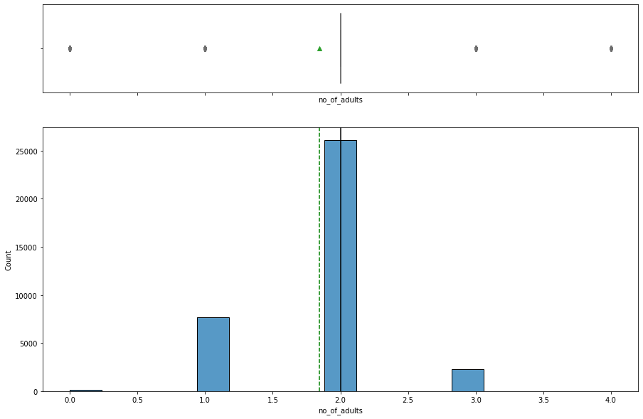

```python
histogram_boxplot(data, "no_of_adults")
```

The average number of adults is 2. There are outliers present on both sides.

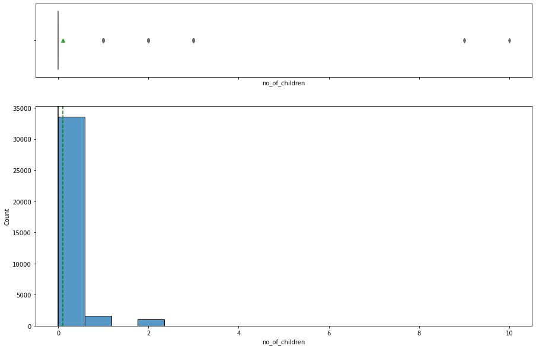

```python
histogram_boxplot(data, "no_of_children")
```

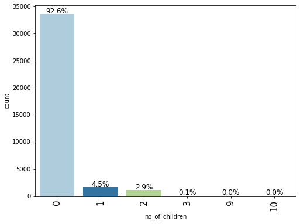

```python
labeled_barplot(data, "no_of_children", perc=True)
```

92.6% of the bookings do not include children. No. of children is right skewed with many outliers on the upper quartile.

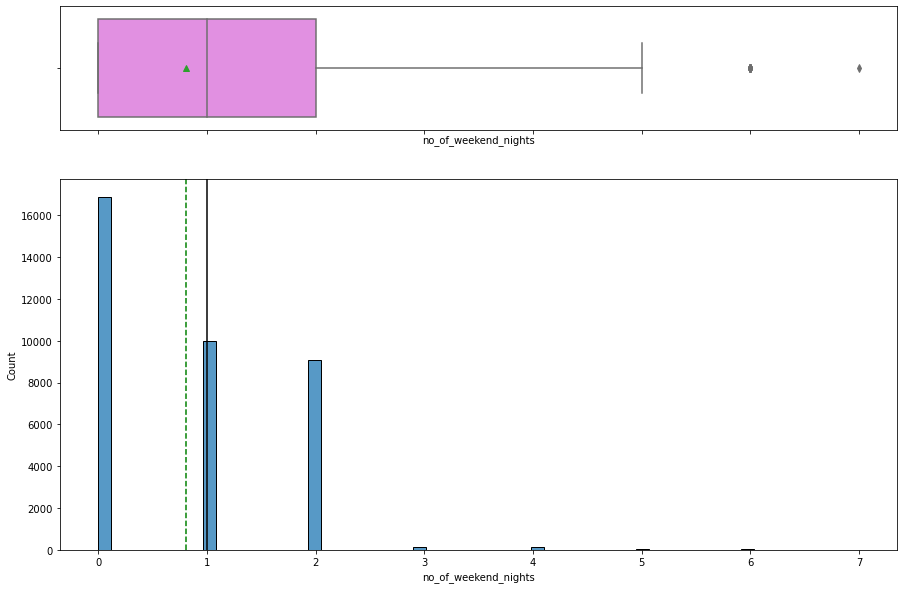

```python
histogram_boxplot(data, "no_of_weekend_nights")
```

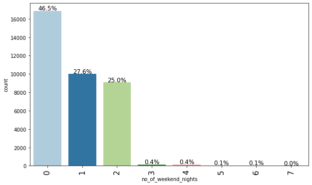

```python
labeled_barplot(data, "no_of_weekend_nights", perc=True)
```

46.5% of all bookings do not include a weekend night.

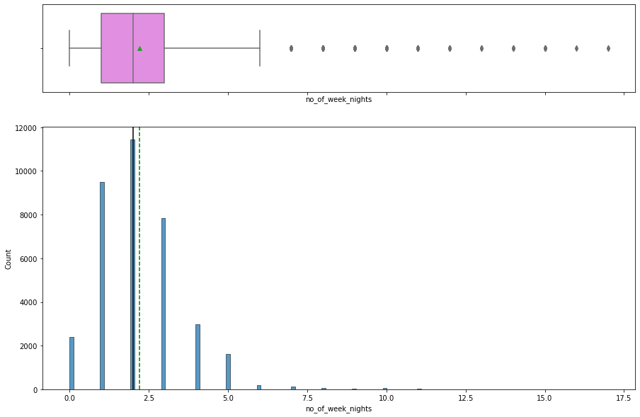

```python
histogram_boxplot(data, "no_of_week_nights")
```

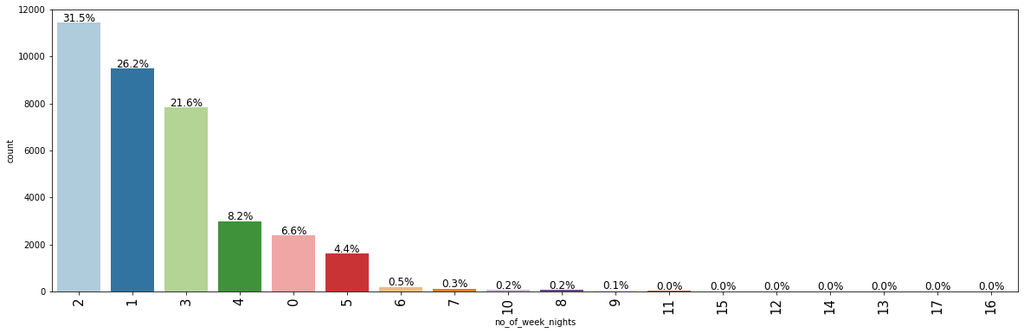

```python
labeled_barplot(data, "no_of_week_nights", perc=True)
```

The most common number of days booked during the week day is 2 nights.

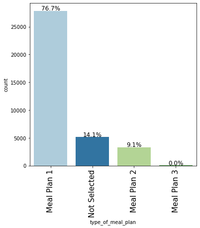

```python
labeled_barplot(data, "type_of_meal_plan", perc=True)
```

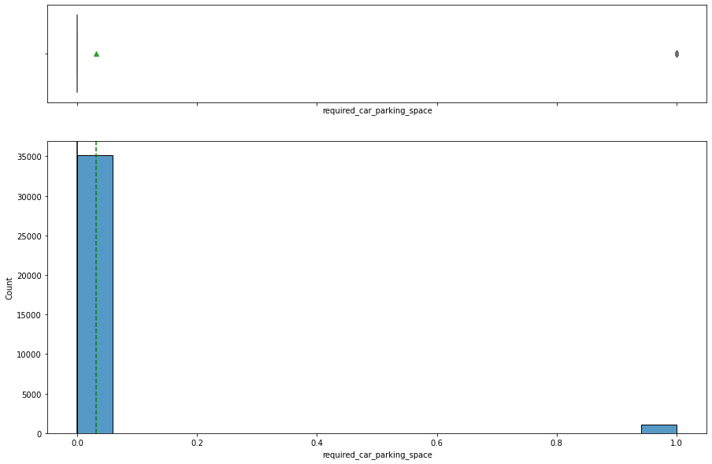

```python
histogram_boxplot(data, "required_car_parking_space")
```

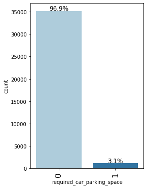

```python
labeled_barplot(data, "required_car_parking_space", perc=True)
```

96.9% of all bookings do not require a car parking space.

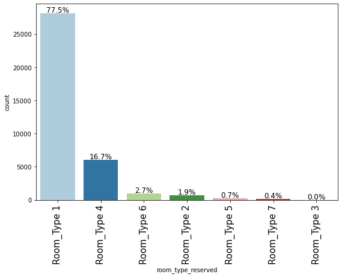

```python
labeled_barplot(data, "room_type_reserved", perc=True)
```

Room Type 1 is the most common room type booked.

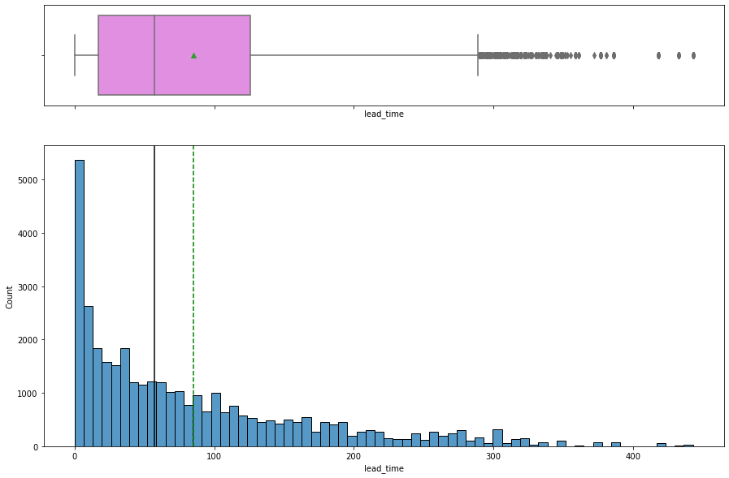

```python
histogram_boxplot(data, "lead_time")
```

```python
data["lead_time"].value_counts()
```

```
0      1297
1      1078
2       643
3       630
4       628
       ...
300       1
353       1
328       1
352       1
351       1
Name: lead_time, Length: 352, dtype: int64
```